# Problema 3 - Checkpoint 1

# Para onde vai o dinheiro das emendas parlamentares?

Com o intuito de avaliar os tipos de despesas que recebem mais atenção dos parlamentares brasileiros, foram analisados dados referentes às emendas parlamentares realizadas entre os anos de 2015 e 2016.

Uma emenda parlamentar é o meio pelo qual um determinado parlamentar pleiteia a obtenção de uma parcela do orçamento anual do país para aplicar em sua área de atuação. Uma emenda parlamentar destinada a uma ação é custeada com recursos de um determinado ministério. Para observar quais áreas recebem mais investimento parlamentar, foram utilizadas as informações sobre o ministério que está custeando a emenda. Durante nossa análise, foi possível observar que os cinco ministérios que mais concentram investimentos dos parlamentares são os ministérios das Cidades, da Saúde, do Turismo, do Esporte e da Agricultura, conforme pode ser observado no gráfico abaixo:

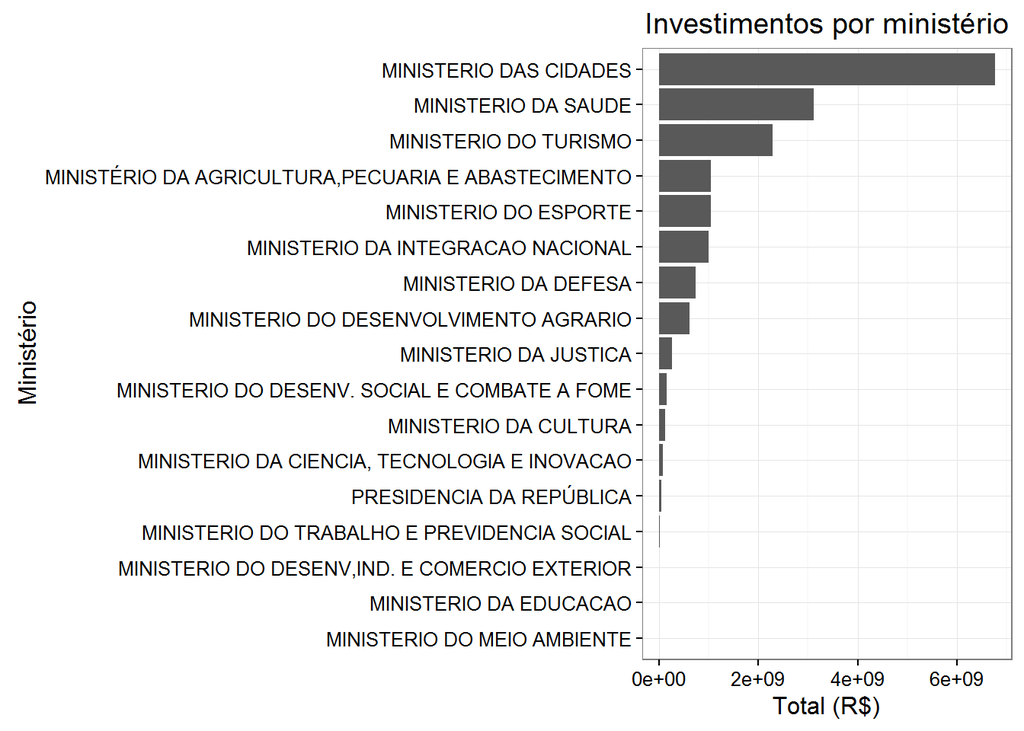

Após tal observação, uma nova pergunta surgiu: Será que os recursos estão distribuídos de forma igualitária entre os estados brasileiros ou há disparidades? Para tentar resolver essa questão, tentamos agrupar os estados brasileiros de acordo com os investimentos feitos pelos parlamentares nas cinco principais áreas já citadas anteriormente por meio das emendas parlamentares.

Devido ao número reduzido de estados, foi o utilizado o método de agrupamento hierárquico, que apresenta melhores resultados que o algoritmo de k-means nessa situação. Para medir a distância entre dois clusters, foi utilizada a distância de Ward. Esse tipo de medição inter-clusters faz com que seja necessária a utilização da distância euclidiana como métrica de distância intra-cluster. A partir da escolha do algoritmo, iniciou-se a busca pela melhor quantidade de grupos.

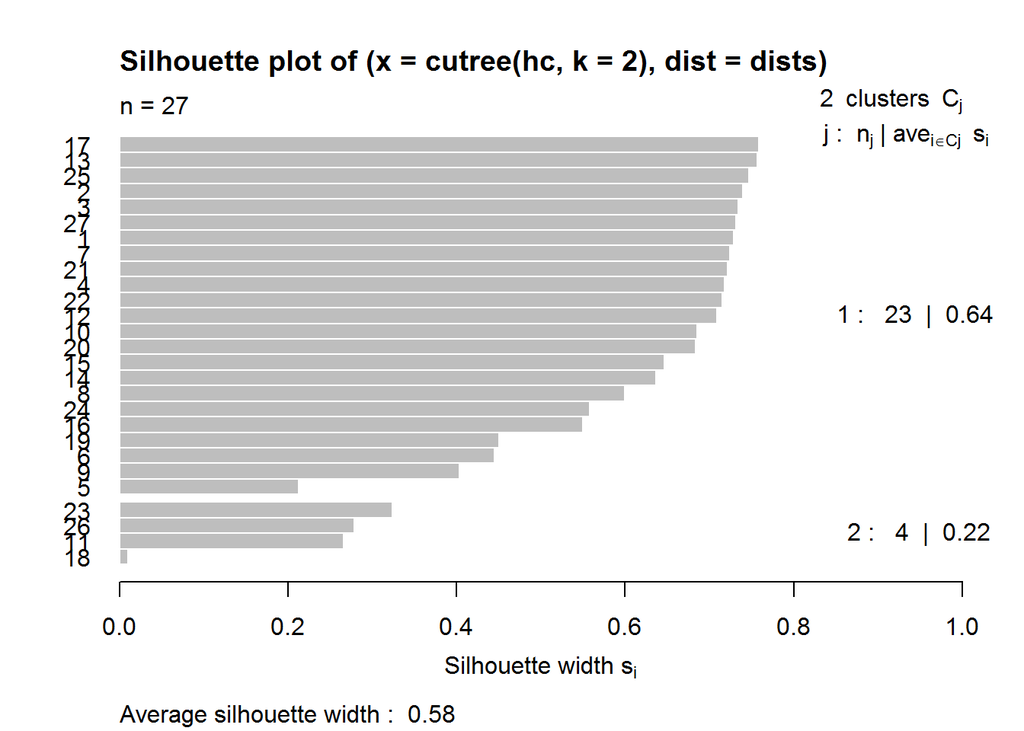

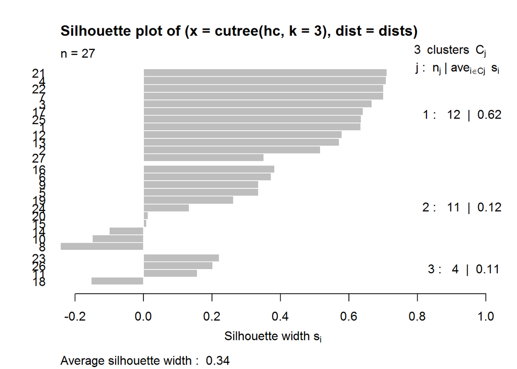

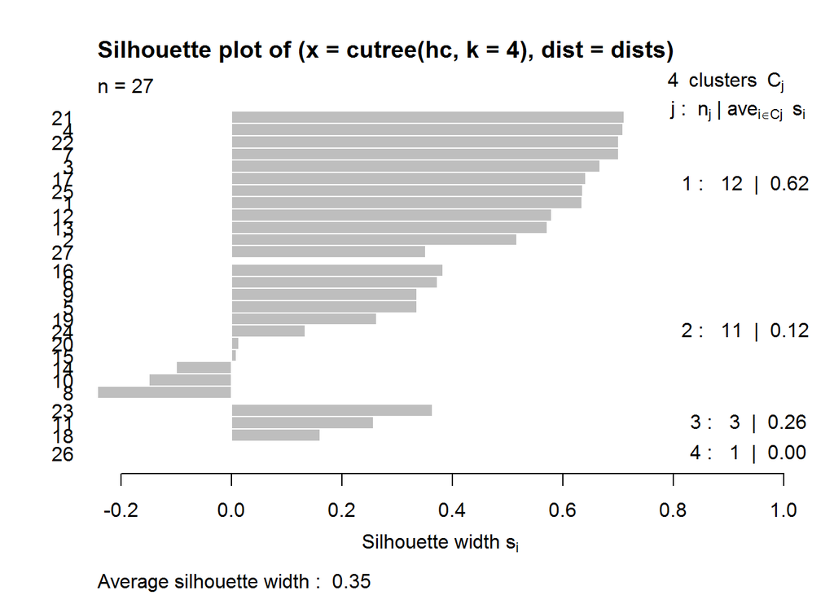

Nesta etapa, foram testados agrupamentos com dois, três e quatro grupos e a partir dos gráficos de silhueta, foi possível perceber que o melhor resultado é obtido ao dividir os estados brasileiros em dois grupos.

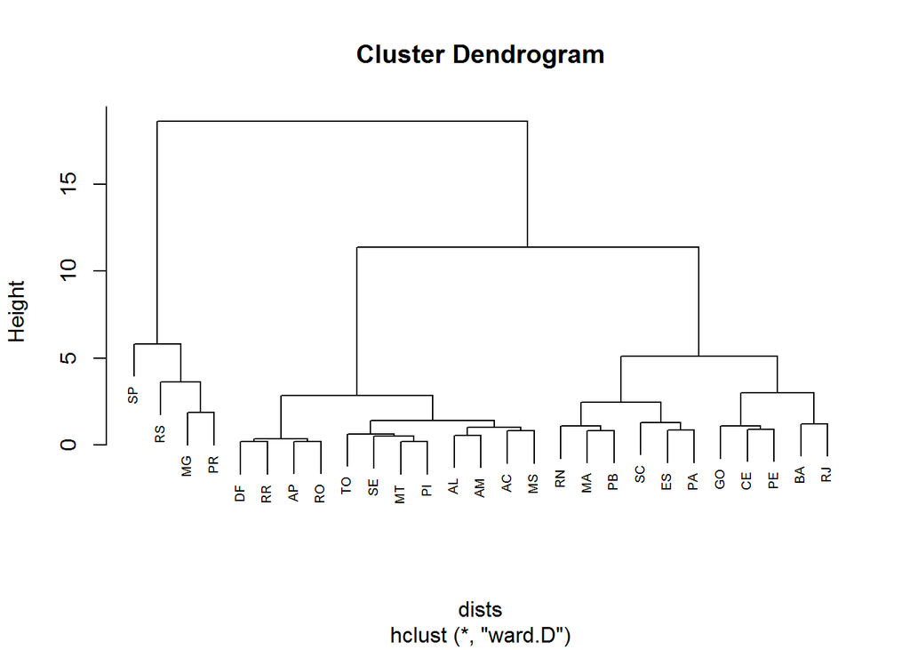

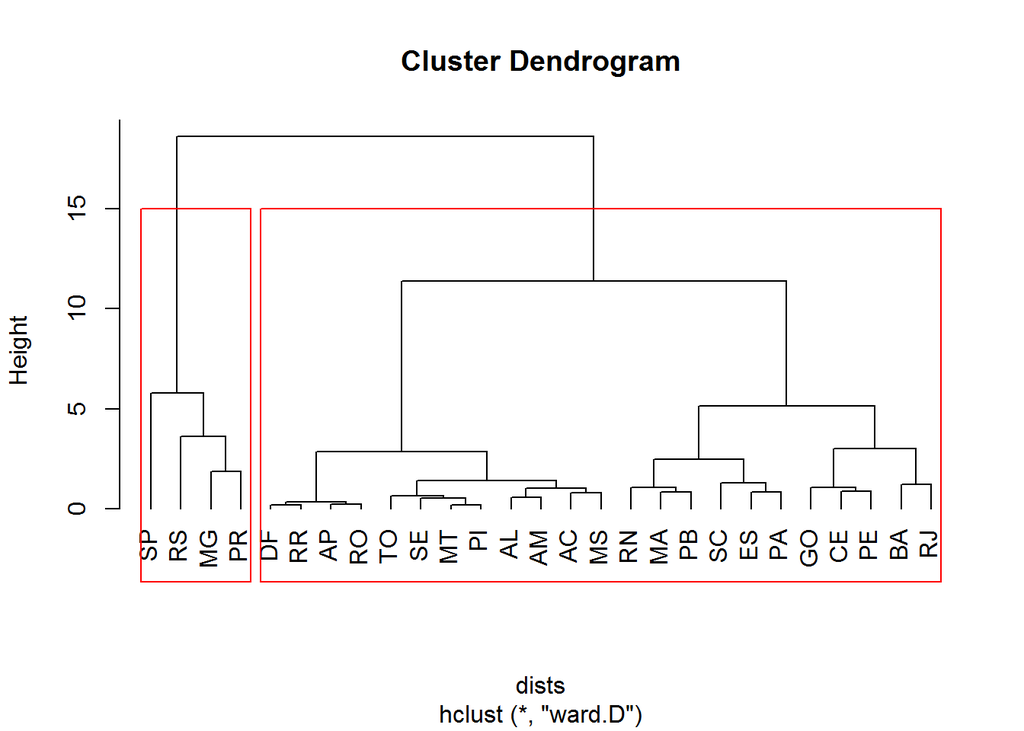

Feito isso, foi possível observar em maiores detalhes como estão distribuídos os investimentos entre os dois grupos obtidos.

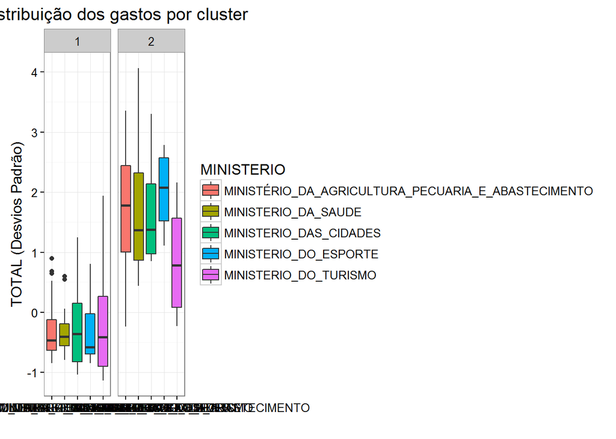